# Week 10 Day 5 - Homework

# Data Dictionary

index Date: The date of the observation AveragePrice: the average price of a single avocado Total Volume: Total number of avocados sold 4046: Total number of avocados with PLU 4046 sold 4225: Total number of avocados with PLU 4225 sold 4770: Total number of avocados with PLU 4770 sold Total Bags Small Bags Large Bags XLarge Bags type: conventional or organic year: the year region: the city or region of the observation

#1 MVP We’ve looked at a few different ways in which we can build models this week, including how to prepare them properly. This weekend we’ll build a multiple linear regression model on a dataset which will need some preparation. The data can be found in the data folder, along with a data dictionary

We want to investigate the avocado dataset, and, in particular, to model the AveragePrice of the avocados. Use the tools we’ve worked with this week in order to prepare your dataset and find appropriate predictors. Once you’ve built your model use the validation techniques discussed on Wednesday to evaluate it. Feel free to focus either on building an explanatory or a predictive model, or both if you are feeling energetic!

As part of the MVP we want you not to just run the code but also have a go at interpreting the results and write your thinking in comments in your script.

Hints and tips

region may lead to many dummy variables. Think carefully about whether to include this variable or not (there is no one ‘right’ answer to this!) Think about whether each variable is categorical or numerical. If categorical, make sure that the variable is represented as a factor. We will not treat this data as a time series, so Date will not be needed in your models, but can you extract any useful features out of Date before you discard it? If you want to build a predictive model, consider using either leaps or glmulti to help with this.

```r
library(lubridate)
```

```r
avocado <- read_csv(here::here("avocado.csv")) %>%
  janitor::clean_names()
```

# Data Exploration

```r
skimr::skim(avocado)
```

```
── Data Summary ────────────────────────
                           Values
Name                       avocado
Number of rows             18249
Number of columns          14
_______________________
Column type frequency:
  character                2
  Date                     1
  numeric                  11
________________________
Group variables            None
```

|  | skim_variable | n_missing | complete_rate | min | max | empty | n_unique | whitespace |
| --- | --- | --- | --- | --- | --- | --- | --- | --- |
| 1 | type | 0 | 1 | 7 | 12 | 0 | 2 | 0 |
| 2 | region | 0 | 1 | 4 | 19 | 0 | 54 | 0 |

|  | skim_variable | n_missing | complete_rate | min | max | median | n_unique |
| --- | --- | --- | --- | --- | --- | --- | --- |
| 1 | date | 0 | 1 | 2015-01-04 | 2018-03-25 | 2016-08-14 | 169 |

|  | skim_variable | n_missing | complete_rate | mean | sd | p0 | p25 | p50 | p75 | p100 | hist |
| --- | --- | --- | --- | --- | --- | --- | --- | --- | --- | --- | --- |
| 1 | x1 | 0 | 1 | 2.423223e+01 | 1.548104e+01 | 0.00 | 10.00 | 24.00 | 38.00 | 52.00 | ▇▆▆▆▆ |
| 2 | average_price | 0 | 1 | 1.405978e+00 | 4.026766e-01 | 0.44 | 1.10 | 1.37 | 1.66 | 3.25 | ▂▇▅▁▁ |
| 3 | total_volume | 0 | 1 | 8.506440e+05 | 3.453545e+06 | 84.56 | 10838.58 | 107376.76 | 432962.29 | 62505646.52 | ▇▁▁▁▁ |
| 4 | x4046 | 0 | 1 | 2.930084e+05 | 1.264989e+06 | 0.00 | 854.07 | 8645.30 | 111020.20 | 22743616.17 | ▇▁▁▁▁ |
| 5 | x4225 | 0 | 1 | 2.951546e+05 | 1.204120e+06 | 0.00 | 3008.78 | 29061.02 | 150206.86 | 20470572.61 | ▇▁▁▁▁ |
| 6 | x4770 | 0 | 1 | 2.283974e+04 | 1.074641e+05 | 0.00 | 0.00 | 184.99 | 6243.42 | 2546439.11 | ▇▁▁▁▁ |
| 7 | total_bags | 0 | 1 | 2.396392e+05 | 9.862424e+05 | 0.00 | 5088.64 | 39743.83 | 110783.37 | 19373134.37 | ▇▁▁▁▁ |
| 8 | small_bags | 0 | 1 | 1.821947e+05 | 7.461785e+05 | 0.00 | 2849.42 | 26362.82 | 83337.67 | 13384586.80 | ▇▁▁▁▁ |
| 9 | large_bags | 0 | 1 | 5.433809e+04 | 2.439660e+05 | 0.00 | 127.47 | 2647.71 | 22029.25 | 5719096.61 | ▇▁▁▁▁ |
| 10 | x_large_bags | 0 | 1 | 3.106427e+03 | 1.769289e+04 | 0.00 | 0.00 | 0.00 | 132.50 | 551693.65 | ▇▁▁▁▁ |

[output cut: 1 more lines]

| x1 | date | average_price | total_volume | x4046 | x4225 | x4770 | total_bags | small_bags | large_bags | x_large_bags | type | year | region |
| --- | --- | --- | --- | --- | --- | --- | --- | --- | --- | --- | --- | --- | --- |
| 0 | 2015-12-27 | 1.33 | 64236.62 | 1036.74 | 54454.85 | 48.16 | 8696.87 | 8603.62 | 93.25 | 0 | conventional | 2015 | Albany |
| 1 | 2015-12-20 | 1.35 | 54876.98 | 674.28 | 44638.81 | 58.33 | 9505.56 | 9408.07 | 97.49 | 0 | conventional | 2015 | Albany |
| 2 | 2015-12-13 | 0.93 | 118220.22 | 794.70 | 109149.67 | 130.50 | 8145.35 | 8042.21 | 103.14 | 0 | conventional | 2015 | Albany |
| 3 | 2015-12-06 | 1.08 | 78992.15 | 1132.00 | 71976.41 | 72.58 | 5811.16 | 5677.40 | 133.76 | 0 | conventional | 2015 | Albany |
| 4 | 2015-11-29 | 1.28 | 51039.60 | 941.48 | 43838.39 | 75.78 | 6183.95 | 5986.26 | 197.69 | 0 | conventional | 2015 | Albany |

[figure not shown]

Average price looks as if it right skewed and so taking a logarithmic could help to create a slighly more normalised data set.

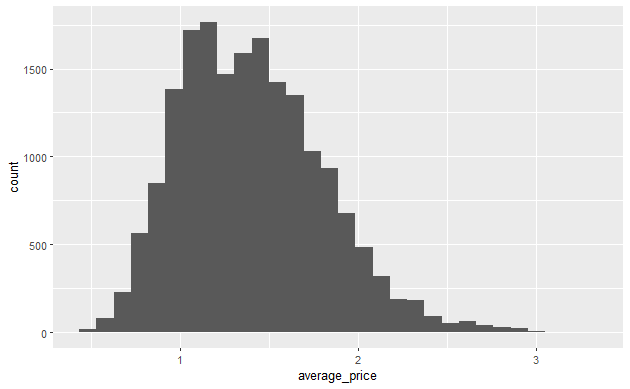

```r
avocado %>%
  ggplot(aes(average_price)) +
  geom_histogram()
```

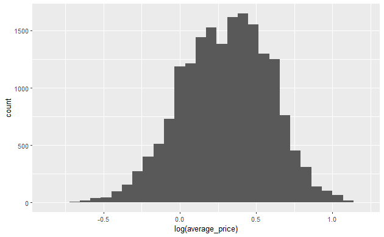

```r
avocado %>%
  ggplot(aes(x = log(average_price))) +
  geom_histogram()
```

Check for the unique values in each

| x1 | date | average_price | total_volume | x4046 | x4225 | x4770 | total_bags | small_bags | large_bags | x_large_bags | type | year | region |
| --- | --- | --- | --- | --- | --- | --- | --- | --- | --- | --- | --- | --- | --- |
| 53 | 169 | 259 | 18237 | 17702 | 18103 | 12071 | 18097 | 17321 | 15082 | 5588 | 2 | 4 | 54 |

| x1 | date | average_price | total_volume | x4046 | x4225 | x4770 | total_bags | small_bags | large_bags | x_large_bags | type | year | region |
| --- | --- | --- | --- | --- | --- | --- | --- | --- | --- | --- | --- | --- | --- |
| 0 | 2015-12-27 | 1.33 | 64236.62 | 1036.74 | 54454.85 | 48.16 | 8696.87 | 8603.62 | 93.25 | 0.00 | conventional | 2015 | Albany |
| 1 | 2015-12-20 | 1.35 | 54876.98 | 674.28 | 44638.81 | 58.33 | 9505.56 | 9408.07 | 97.49 | NA | NA | NA | NA |
| 2 | 2015-12-13 | 0.93 | 118220.22 | 794.70 | 109149.67 | 130.50 | 8145.35 | 8042.21 | 103.14 | NA | NA | NA | NA |
| 3 | 2015-12-06 | 1.08 | 78992.15 | 1132.00 | 71976.41 | 72.58 | 5811.16 | 5677.40 | 133.76 | NA | NA | NA | NA |
| 4 | 2015-11-29 | 1.28 | 51039.60 | 941.48 | 43838.39 | 75.78 | 6183.95 | 5986.26 | 197.69 | NA | NA | NA | NA |
| 5 | 2015-11-22 | 1.26 | 55979.78 | 1184.27 | 48067.99 | 43.61 | 6683.91 | 6556.47 | 127.44 | NA | NA | NA | NA |
| 6 | 2015-11-15 | 0.99 | 83453.76 | 1368.92 | 73672.72 | 93.26 | 8318.86 | 8196.81 | 122.05 | NA | NA | NA | NA |
| 7 | 2015-11-08 | 0.98 | 109428.33 | 703.75 | 101815.36 | 80.00 | 6829.22 | 6266.85 | 562.37 | NA | NA | NA | NA |
| 8 | 2015-11-01 | 1.02 | 99811.42 | 1022.15 | 87315.57 | 85.34 | 11388.36 | 11104.53 | 283.83 | NA | NA | NA | NA |
| 9 | 2015-10-25 | 1.07 | 74338.76 | 842.40 | 64757.44 | 113.00 | 8625.92 | 8061.47 | 564.45 | NA | NA | NA | NA |

[output cut: 990 more lines]

Check to see if there are aliases within the data set.

```r
alias(average_price ~ ., data = avocado)
```

Whilst this did no appear in the above. Total bags is the summation of small, large and xl bags and so will be removed from the data set.

```r
avocado %>%
  mutate(check = total_bags - small_bags - large_bags - x_large_bags) %>%
  slice_max(check,n=5)
```

| x1 | date | average_price | total_volume | x4046 | x4225 | x4770 | total_bags | small_bags | large_bags | x_large_bags | type | year | region | check |
| --- | --- | --- | --- | --- | --- | --- | --- | --- | --- | --- | --- | --- | --- | --- |
| 4 | 2017-12-03 | 1.07 | 504933 | 263807 | 32457 | 1390 | 207280 | 137581 | 66640 | 3058 | conventional | 2017 | Atlanta | 1 |
| 5 | 2017-11-26 | 1.43 | 629719 | 59916 | 377227 | 3440 | 189136 | 157579 | 31556 | 0 | conventional | 2017 | BaltimoreWashington | 1 |
| 5 | 2017-11-26 | 1.44 | 54681 | 28307 | 1707 | 5116 | 19551 | 14540 | 4914 | 96 | conventional | 2017 | Boise | 1 |
| 7 | 2017-11-12 | 1.23 | 81827 | 37876 | 2047 | 4630 | 37274 | 32441 | 4811 | 21 | conventional | 2017 | Boise | 1 |
| 5 | 2017-11-26 | 1.39 | 423778 | 10677 | 304833 | 2073 | 106195 | 65656 | 40538 | 0 | conventional | 2017 | Boston | 1 |
| 7 | 2017-11-12 | 1.23 | 639092 | 15689 | 533027 | 5720 | 84655 | 74568 | 10086 | 0 | conventional | 2017 | Boston | 1 |
| 5 | 2017-11-26 | 1.70 | 506394 | 71736 | 278263 | 82294 | 74100 | 68552 | 5532 | 15 | conventional | 2017 | Chicago | 1 |
| 7 | 2017-11-12 | 0.90 | 324830 | 5473 | 119880 | 868 | 198609 | 16033 | 182385 | 190 | conventional | 2017 | CincinnatiDayton | 1 |
| 6 | 2017-11-19 | 0.94 | 958421 | 561075 | 167540 | 3568 | 226238 | 137522 | 88658 | 57 | conventional | 2017 | DallasFtWorth | 1 |
| 7 | 2017-11-12 | 0.96 | 1054327 | 509106 | 271438 | 4615 | 269169 | 120695 | 148352 | 121 | conventional | 2017 | DallasFtWorth | 1 |

[output cut: 34 more lines]

| check | total_volume | x4046 | x4225 | x4770 |
| --- | --- | --- | --- | --- |
| 8696.87 | 64236.62 | 1036.74 | 54454.85 | 48.16 |
| 9505.56 | 54876.98 | 674.28 | 44638.81 | 58.33 |
| 8145.35 | 118220.22 | 794.70 | 109149.67 | 130.50 |
| 5811.16 | 78992.15 | 1132.00 | 71976.41 | 72.58 |
| 6183.95 | 51039.60 | 941.48 | 43838.39 | 75.78 |
| 6683.91 | 55979.78 | 1184.27 | 48067.99 | 43.61 |
| 8318.86 | 83453.76 | 1368.92 | 73672.72 | 93.26 |
| 6829.22 | 109428.33 | 703.75 | 101815.36 | 80.00 |
| 11388.36 | 99811.42 | 1022.15 | 87315.57 | 85.34 |
| 8625.92 | 74338.76 | 842.40 | 64757.44 | 113.00 |

[output cut: 990 more lines]

| region |
| --- |
| Albany |
| Atlanta |
| BaltimoreWashington |
| Boise |
| Boston |
| BuffaloRochester |
| California |
| Charlotte |
| Chicago |
| CincinnatiDayton |

[output cut: 44 more lines]

| type |
| --- |
| conventional |
| organic |

# Data Engineering

```r
avocado_tidy <- avocado %>%
  mutate(month = month(date, label = TRUE),
         year = as.factor(year)) %>%
  select(-c(x1,date, total_bags. region)) %>%
```

[output not shown]

## Split in to training and validation

```r
test_index <- sample(1:nrow(avocado_tidy), size = nrow(avocado_tidy)*0.1)

avocado_train <- slice(avocado_tidy, -test_inddex)
avocado_test <- slice(avocado_tidy, test_inddex)
```

# Manual Model Creation

Function for easier plots later:

```r
ggpairs_plots <- function(data, main_columns){
  data %>%
    select(where(is.numeric), main_columns, type) %>%
    ggpairs(aes(colour = type), progress = FALSE) %>%
    print()

  data %>%
    select(-where(is.numeric), main_columns ,type) %>%
    ggpairs(aes(colour = type), progress = FALSE) %>%
    print()
}
```

Review the correlation of variables. From the initial look, there does not appear to be any clear correlation between average price and any of the other variables

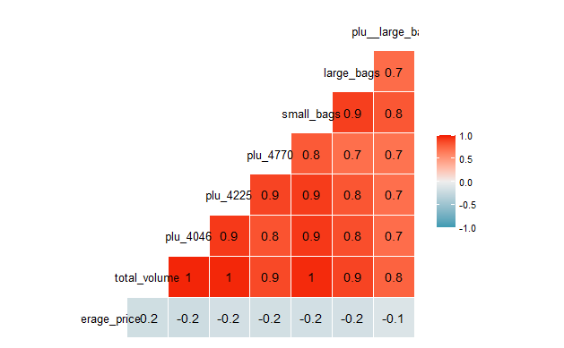

```r
avocado_train %>%
  ggcorr(label = TRUE)
```

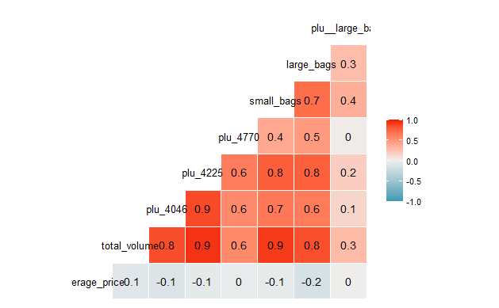

```r
avocado_train %>%
  filter(type == "organic") %>%
  ggcorr(label = TRUE)
```

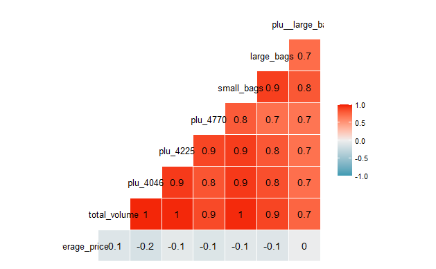

```r
avocado_train %>%
  filter(type != "organic") %>%
  ggcorr(label = TRUE)
```

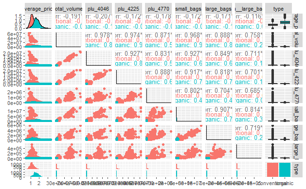

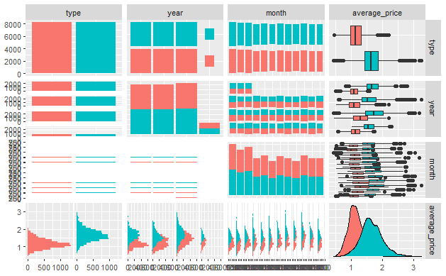

## Model 1

From the ggpairs plots the type has a large effect on the average price. The month also has an affect

### Type

```r
model_1_type <- lm(average_price ~ type,
                   data = avocado_train)

summary(model_1_type)
```

```
Call:
lm(formula = average_price ~ type, data = avocado_train)

Residuals:
     Min       1Q   Median       3Q      Max
-1.21466 -0.20466 -0.02879  0.18534  1.59534

Coefficients:
            Estimate Std. Error t value Pr(>|t|)
(Intercept) 1.158795   0.003514  329.74   <2e-16 ***
typeorganic 0.495861   0.004965   99.87   <2e-16 ***
---
Signif. codes:  0 ‘***’ 0.001 ‘**’ 0.01 ‘*’ 0.05 ‘.’ 0.1 ‘ ’ 1

Residual standard error: 0.3182 on 16423 degrees of freedom
Multiple R-squared:  0.3779,    Adjusted R-squared:  0.3778
F-statistic:  9975 on 1 and 16423 DF,  p-value: < 2.2e-16
```

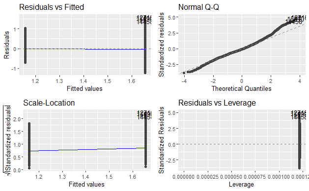

```r
autoplot(model_1_type)
```

```r
model_1_type_log <- lm(log(average_price) ~ type,
                   data = avocado_train)

summary(model_1_type_log)
```

```
Call:
lm(formula = log(average_price) ~ type, data = avocado_train)

Residuals:
     Min       1Q   Median       3Q      Max
-1.29948 -0.13491  0.00392  0.14849  0.70015

Coefficients:
            Estimate Std. Error t value Pr(>|t|)
(Intercept) 0.121540   0.002525   48.14   <2e-16 ***
typeorganic 0.356964   0.003567  100.07   <2e-16 ***
---
Signif. codes:  0 ‘***’ 0.001 ‘**’ 0.01 ‘*’ 0.05 ‘.’ 0.1 ‘ ’ 1

Residual standard error: 0.2286 on 16423 degrees of freedom
Multiple R-squared:  0.3788,    Adjusted R-squared:  0.3788
F-statistic: 1.001e+04 on 1 and 16423 DF,  p-value: < 2.2e-16
```

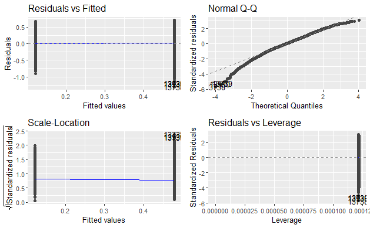

```r
autoplot(model_1_type_log)
```

#### Discussion

The model with type seems to be statistically significant. The organic type will increase the average price by 0.495.

### total_volume

```r
model_1_tot_vol <- lm(average_price ~ total_volume,
                   data = avocado_train)

summary(model_1_tot_vol)
```

```
Call:
lm(formula = average_price ~ total_volume, data = avocado_train)

Residuals:
     Min       1Q   Median       3Q      Max
-0.98462 -0.29910 -0.03431  0.25406  1.82432

Coefficients:
               Estimate Std. Error t value Pr(>|t|)
(Intercept)   1.426e+00  3.180e-03  448.42   <2e-16 ***
total_volume -2.238e-08  8.973e-10  -24.94   <2e-16 ***
---
Signif. codes:  0 ‘***’ 0.001 ‘**’ 0.01 ‘*’ 0.05 ‘.’ 0.1 ‘ ’ 1

Residual standard error: 0.3959 on 16423 degrees of freedom
Multiple R-squared:  0.0365,    Adjusted R-squared:  0.03644
F-statistic: 622.1 on 1 and 16423 DF,  p-value: < 2.2e-16
```

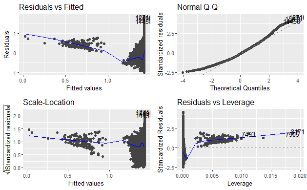

```r
autoplot(model_1_tot_vol)
```

#### Discussion

Whilst the values are significant the r2 is lower than the type. There is also a large deviation in the residuals. The first group is no around 0, where the second group is mainly over presidcted.

### plu 4046

```r
model_1_plu4046 <- lm(average_price ~ plu_4046,
                   data = avocado_train)

summary(model_1_tot_vol)
```

```
Call:
lm(formula = average_price ~ total_volume, data = avocado_train)

Residuals:
     Min       1Q   Median       3Q      Max
-0.98462 -0.29910 -0.03431  0.25406  1.82432

Coefficients:
               Estimate Std. Error t value Pr(>|t|)
(Intercept)   1.426e+00  3.180e-03  448.42   <2e-16 ***
total_volume -2.238e-08  8.973e-10  -24.94   <2e-16 ***
---
Signif. codes:  0 ‘***’ 0.001 ‘**’ 0.01 ‘*’ 0.05 ‘.’ 0.1 ‘ ’ 1

Residual standard error: 0.3959 on 16423 degrees of freedom
Multiple R-squared:  0.0365,    Adjusted R-squared:  0.03644
F-statistic: 622.1 on 1 and 16423 DF,  p-value: < 2.2e-16
```

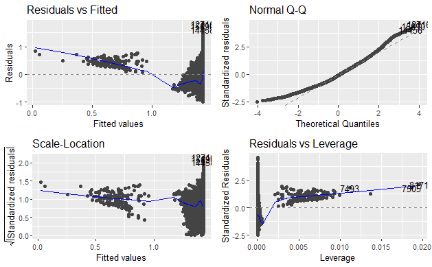

```r
autoplot(model_1_tot_vol)
```

#### Discussion

> Model 1 champion = type

## Model 2

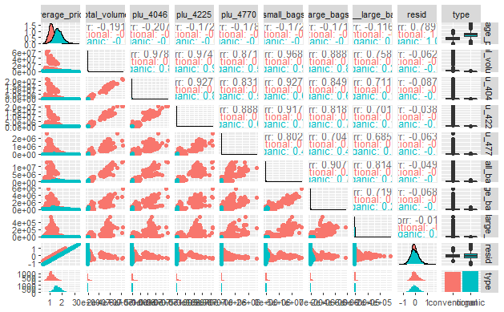

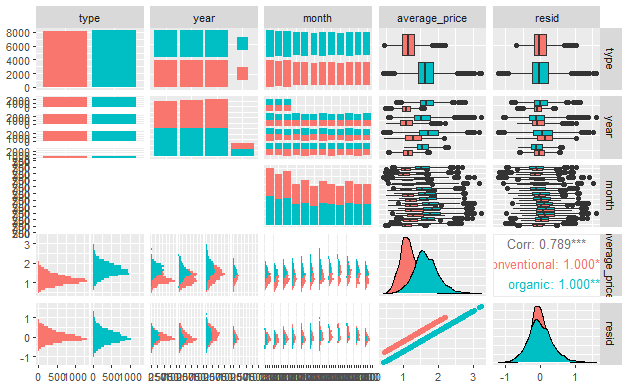

### month

```r
model_2_month <- lm(average_price ~ type + month,
                   data = avocado_train)
summary(model_2_month)
autoplot(model_2_month)
```

[output not shown]

```r
model_2_year <- lm(average_price ~ type + year,
                   data = avocado_train)
summary(model_2_year)
autoplot(model_2_year)
```

[output not shown]

```r
model_2_total_volume <- lm(average_price ~ type + total_volume,
                   data = avocado_train)
summary(model_2_month)
autoplot(model_2_month)
```

[output not shown]

# Automated model

```r
library(leaps)
```

```r
auto_avocado_forward <- regsubsets(average_price ~ .,
                                   data = avocado_train,
                                   method = "forward")
```

## glmulti

```r
library(glmulti)
```

```r
glmulti_model <- glmulti(
    average_price ~ .,
  data = avocado_train,
  level = 2, # 2 = include pairwise interactions, 1 = main effects only (main effect = no pairwise interactions)
  minsize = 0, # no min size of model
  maxsize = -1, # -1 = no max size of model
  marginality = TRUE, # marginality here means the same as 'strongly hierarchical' interactions, i.e. include pairwise interactions only if both predictors present in the model as main effects.
  method = "g", # the problem is too large for exhaustive search, so search using a genetic algorithm
  crit = bic, # criteria for model selection is BIC value (lower is better)
  plotty = FALSE, # don't plot models as function runs
  report = TRUE, # do produce reports as function runs
  confsetsize = 100, # return best 100 solutions
  fitfunction = lm # fit using the `lm` function
)
```

After 980 generations: Best model: average_price~1+year+month+total_volume+plu_4046+plu_4225+plu_4770+small_bags+large_bags+x_large_bags+type+month:year+plu_4225:plu_4046+large_bags:total_volume+large_bags:plu_4225+x_large_bags:small_bags+type:total_volume+type:plu_4046+type:plu_4225+type:plu_4770+type:small_bags+type:large_bags+year:plu_4225+year:small_bags+year:type Crit= 3934.8192794576 Mean crit= 4073.78480292395 Change in best IC: 0 / Change in mean IC: 0